# MA611 Assignment 6

Ignacio Carracedo

November 5th, 2016

**1.a. Find the best ARMA model for the series. Be sure to justify your choice of model and confirm all assumptions.**

First, we plot the data:

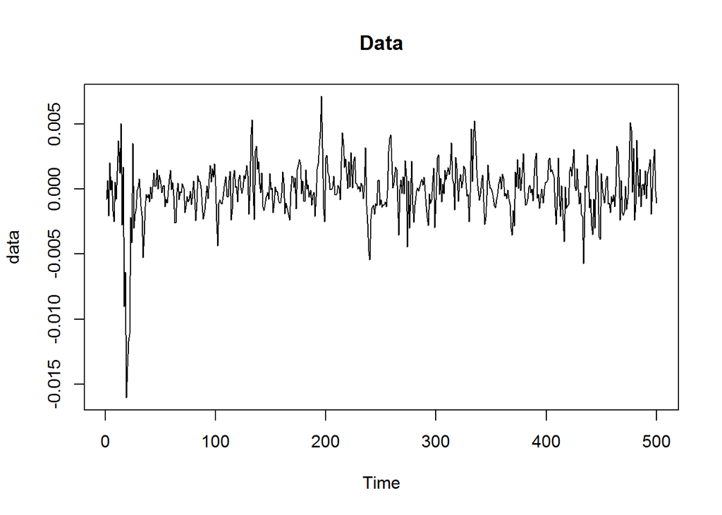

Inspecting the plot visually it seems that the series has a volatility cluster at the beginning where there is a higher variance. Variance seems to remain constant the rest of the series.

We are going to fit the linear component of the model using an ARMA(p,q) model:

x(t) = alpha0 + alpha1 x(t-1) + … + alphap x(t-p) + beta1 a(t-1) + … + betaq a(t-q) + at

Let’s first check if the mean of the series is 0 to see if we need the constant alpha0. We’ll test null hypothesis mean=0:

```
##   Start Size          Mean Standard.Deviation  Skewness Excess.Kurtosis
## 1     1  500 -9.802972e-05        0.002157711 -1.831625        11.59205
##       Minimum     Maximum
## 1 -0.01604065 0.007115596
```

```
## [1] 0.8451606
```

p-value (`0.8451606`) for mean = 0 is much higher than the significant level (5%) so we don’t reject the null hypothesis and conclude that the mean is 0, thus, we won’t need a constant for our ARMA(p,q) model:

x(t) = alpha1 x(t-1) + … + alphap x(t-p) + beta1 a(t-1) + … + betaq a(t-q) + at

Now, we check auto correlation and partial auto correlation plots to get a sense of that the parameters ‘p’ and ‘q’ might be:

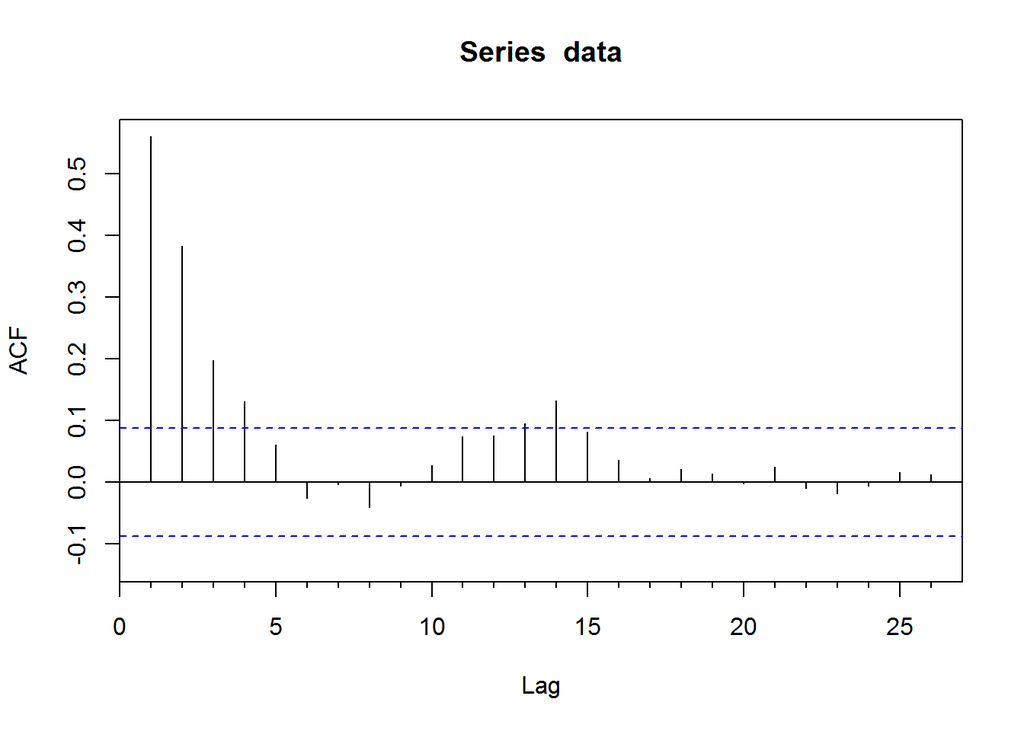

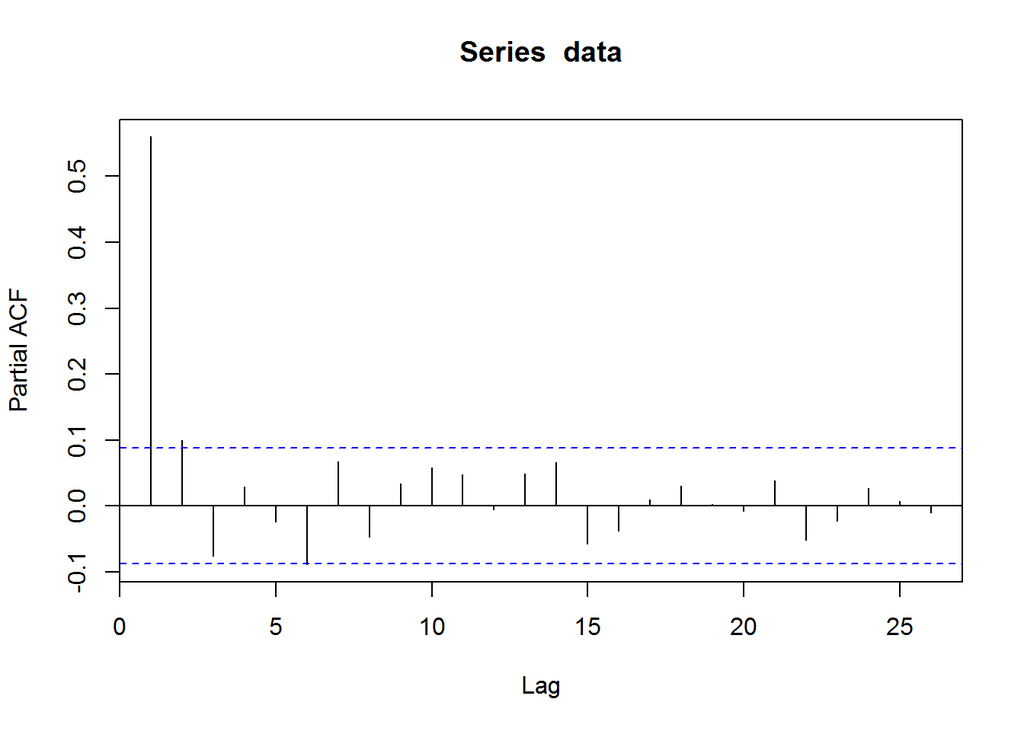

`Acf` and `pacf` are difficult to interpret, `Acf` seems to be decaying (having significant lags at 3 and 4) and `pacf` seems to cut off after 2nd lag but there are other lags close to significance level. To check what ARMA(p,q) model works best we can use the function `auto.arima` and compare models using AIC (which penalizes complexity of the model):

[output not shown]

```
## Series: data
## ARIMA(3,0,2) with zero mean
##
## Coefficients:
##           ar1     ar2     ar3     ma1     ma2
##       -1.0821  0.1334  0.5407  1.6059  0.8272
## s.e.   0.1398  0.1089  0.0719  0.1556  0.1559
##
## sigma^2 estimated as 3.131e-06:  log likelihood=2461.3
## AIC=-4910.6   AICc=-4910.43   BIC=-4885.31
```

ARMA(p=3,q=2) has the best AIC value, let’s fit the model:

```
##
## Call:
## arima(x = data, order = c(3, 0, 2), include.mean = FALSE, fixed = c(NA, NA,
##     NA, NA, NA))
##
## Coefficients:
##           ar1     ar2     ar3     ma1     ma2
##       -1.0821  0.1334  0.5407  1.6059  0.8272
## s.e.   0.1398  0.1089  0.0719  0.1556  0.1559
##
## sigma^2 estimated as 3.1e-06:  log likelihood = 2461.3,  aic = -4910.6
```

As we can see ar2 is not significant so we’ll fit the model again removing this coefficient:

```
##
## Call:
## arima(x = data, order = c(3, 0, 2), include.mean = FALSE, fixed = c(NA, 0, NA,
##     NA, NA))
##
## Coefficients:
##           ar1  ar2     ar3     ma1     ma2
##       -0.5667    0  0.3733  1.0927  0.6975
## s.e.   0.2218    0  0.1038  0.2125  0.1104
##
## sigma^2 estimated as 3.115e-06:  log likelihood = 2460.11,  aic = -4910.21
```

Let’s check the diagnostic plots of our model:

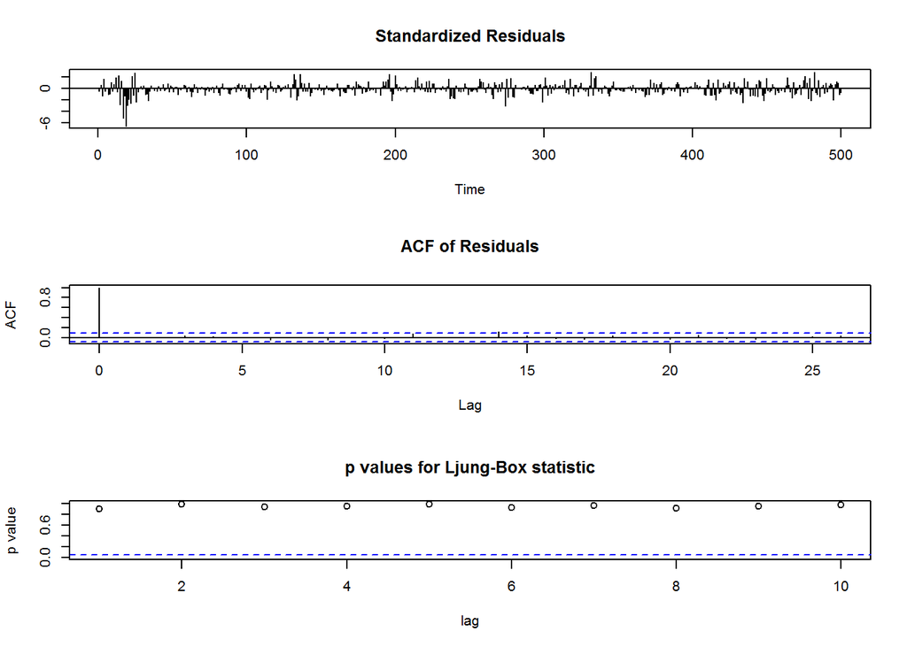

The residuals seem to have no correlation as we can see in the p-values plot for Ljung-Box test. But the variance is higher at the beginning of the series while it remains approximately constant for the rest indicating that there is a high volatility cluster at the beginning of the series (conditional heteroscedasticity).

**1.b. Use the residuals from the model to test for conditional heteroscedasticity (test at 6 and 12 lags).**

To test for conditional heteroscedasticity we need to check of the ACF and PACF of the squared residuals:

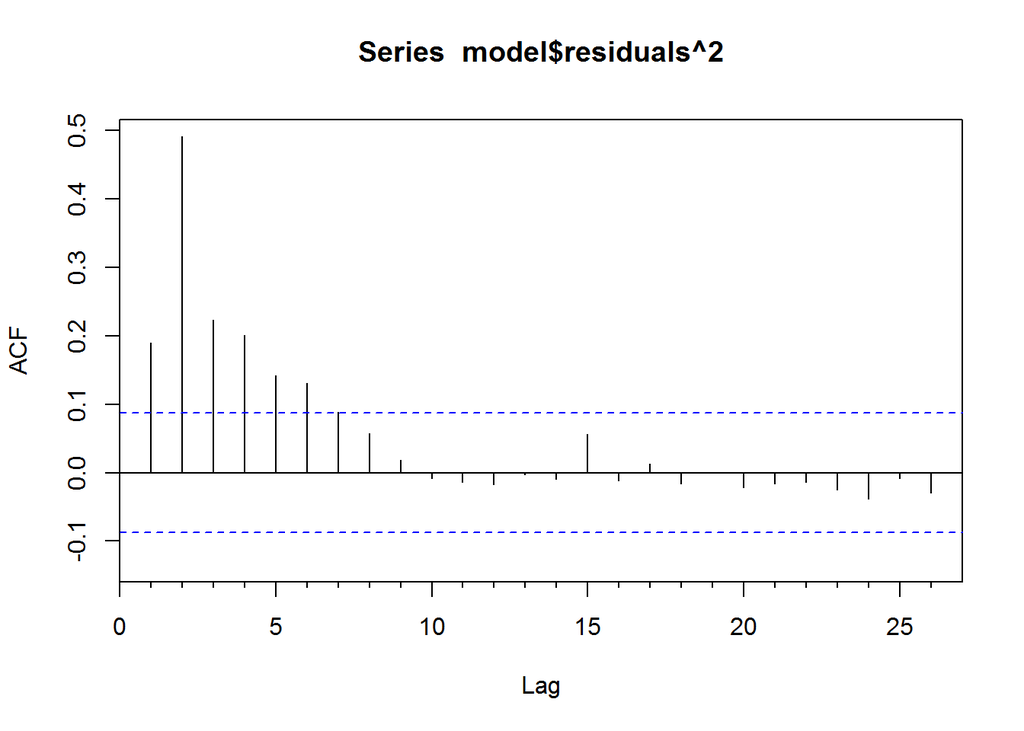

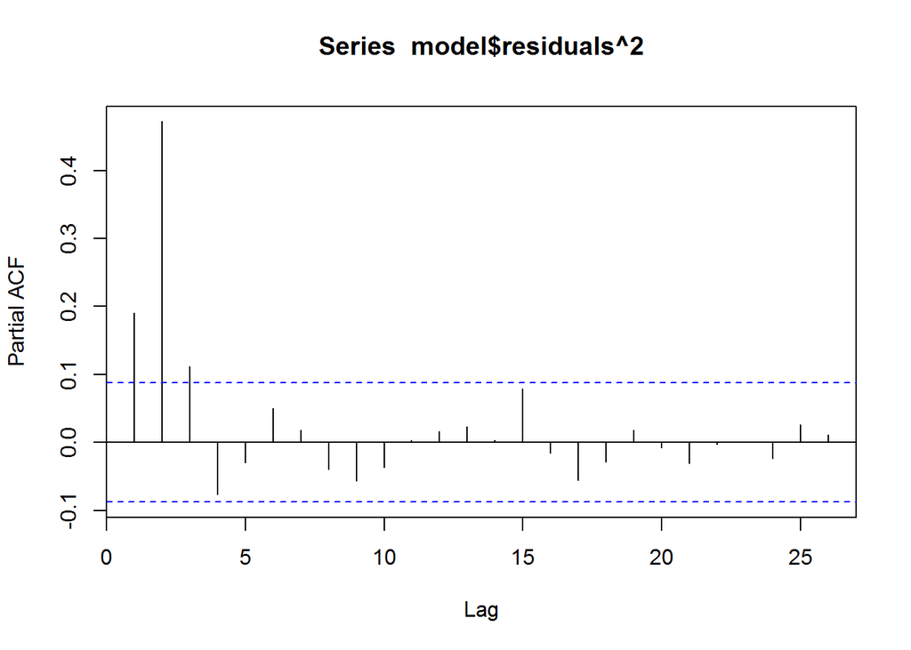

As we can see on the Acf plot it seems there is correlation for at least the first 6 lags. Let use the `ArchTest` which performs the Box-Ljung test at lag n on the auto correlations of the squared series values. Null hypothesis is that there is no correlation at lag n:

```
##
##  ARCH LM-test; Null hypothesis: no ARCH effects
##
## data:  model$residuals
## Chi-squared = 133.1, df = 6, p-value < 2.2e-16
```

```
##
##  ARCH LM-test; Null hypothesis: no ARCH effects
##
## data:  model$residuals
## Chi-squared = 134.85, df = 12, p-value < 2.2e-16
```

The p-value for both tests is lower that the significant level (5%) so we reject the null hypothesis and assume there is significant correlation at both lag 6 and 12, thus, there are conditional heteroscedastic effects.

**1.c. If there are conditional heteroscedastic effects, identify a GARCH model for the data and refit the complete model.**

Checking the partial auto correlation plot we see that it cuts off after lag 2 (lag 3 is still significant but it very small so we won’t take it into account), thus we are going to fit a GARCH(m=2,s=0) model on top of our previous ARMA(3,2) model. Notice we use all of the coefficients of the ARMA(3,2) model to fit GARCH:

```
##
## Title:
##  GARCH Modelling
##
## Call:
##  garchFit(formula = ~arma(3, 2) + garch(2, 0), data = data, trace = FALSE)
##
## Mean and Variance Equation:
##  data ~ arma(3, 2) + garch(2, 0)
## <environment: 0x000000000d9a3358>
##  [data = data]
##
## Conditional Distribution:
##  norm
##
## Coefficient(s):
##          mu          ar1          ar2          ar3          ma1
## -9.0179e-06  -4.7845e-01   2.0481e-01   9.8120e-02   1.0000e+00
##         ma2        omega       alpha1       alpha2
##  2.8325e-01   7.8767e-07   3.1625e-01   4.8033e-01
##
## Std. Errors:
##  based on Hessian
##
## Error Analysis:
##          Estimate  Std. Error  t value Pr(>|t|)
## mu     -9.018e-06   1.131e-04   -0.080   0.9365
## ar1    -4.785e-01   4.152e-01   -1.152   0.2492
## ar2     2.048e-01   1.908e-01    1.073   0.2831
## ar3     9.812e-02   1.935e-01    0.507   0.6122
## ma1     1.000e+00   4.157e-01    2.406   0.0161 *
## ma2     2.833e-01   3.842e-01    0.737   0.4610
## omega   7.877e-07   1.199e-07    6.570 5.02e-11 ***
## alpha1  3.163e-01   7.541e-02    4.194 2.74e-05 ***
## alpha2  4.803e-01   9.086e-02    5.287 1.25e-07 ***
## ---
## Signif. codes:  0 '***' 0.001 '**' 0.01 '*' 0.05 '.' 0.1 ' ' 1
##
## Log Likelihood:
##  2556.651    normalized:  5.113301
##
## Description:
##  Tue Nov 08 17:27:57 2016 by user: carrai1
##
##
## Standardised Residuals Tests:
##                                 Statistic p-Value
##  Jarque-Bera Test   R    Chi^2  0.2115975 0.8996057
##  Shapiro-Wilk Test  R    W      0.9976942 0.7293023
##  Ljung-Box Test     R    Q(10)  4.207151  0.9375185
##  Ljung-Box Test     R    Q(15)  11.86051  0.6895555
##  Ljung-Box Test     R    Q(20)  17.09646  0.6467012
##  Ljung-Box Test     R^2  Q(10)  4.324805  0.9315072
##  Ljung-Box Test     R^2  Q(15)  7.784435  0.9321337
##  Ljung-Box Test     R^2  Q(20)  13.88476  0.8362905
##  LM Arch Test       R    TR^2   7.204009  0.8438424
##
## Information Criterion Statistics:
##       AIC       BIC       SIC      HQIC
## -10.19060 -10.11474 -10.19124 -10.16083
```

ma2 is insignificant so we remove it and fit again:

```
##
## Title:
##  GARCH Modelling
##
## Call:
##  garchFit(formula = ~arma(3, 1) + garch(2, 0), data = data, trace = FALSE)
##
## Mean and Variance Equation:
##  data ~ arma(3, 1) + garch(2, 0)
## <environment: 0x000000000c953c28>
##  [data = data]
##
## Conditional Distribution:
##  norm
##
## Coefficient(s):
##          mu          ar1          ar2          ar3          ma1
## -5.7760e-06  -2.2643e-01   3.6187e-01  -3.0150e-02   7.4312e-01
##       omega       alpha1       alpha2
##  7.9616e-07   3.1699e-01   4.7697e-01
##
## Std. Errors:
##  based on Hessian
##
## Error Analysis:
##          Estimate  Std. Error  t value Pr(>|t|)
## mu     -5.776e-06   8.686e-05   -0.066   0.9470
## ar1    -2.264e-01   9.899e-02   -2.288   0.0222 *
## ar2     3.619e-01   6.038e-02    5.993 2.05e-09 ***
## ar3    -3.015e-02   3.844e-02   -0.784   0.4328
## ma1     7.431e-01   9.004e-02    8.253 2.22e-16 ***
## omega   7.962e-07   1.182e-07    6.734 1.65e-11 ***
## alpha1  3.170e-01   7.559e-02    4.193 2.75e-05 ***
## alpha2  4.770e-01   8.990e-02    5.306 1.12e-07 ***
## ---
## Signif. codes:  0 '***' 0.001 '**' 0.01 '*' 0.05 '.' 0.1 ' ' 1
##
## Log Likelihood:
##  2555.353    normalized:  5.110706
##
## Description:
##  Tue Nov 08 17:27:57 2016 by user: carrai1
##
##
## Standardised Residuals Tests:
##                                 Statistic p-Value
##  Jarque-Bera Test   R    Chi^2  0.1859344 0.9112234
##  Shapiro-Wilk Test  R    W      0.9975789 0.689132
##  Ljung-Box Test     R    Q(10)  4.585919  0.9170702
##  Ljung-Box Test     R    Q(15)  12.30349  0.6559273
##  Ljung-Box Test     R    Q(20)  17.73136  0.6050999
##  Ljung-Box Test     R^2  Q(10)  4.893741  0.8981622
##  Ljung-Box Test     R^2  Q(15)  8.015399  0.9231639
##  Ljung-Box Test     R^2  Q(20)  14.21161  0.819607
##  LM Arch Test       R    TR^2   7.284243  0.8382722
##
## Information Criterion Statistics:
##       AIC       BIC       SIC      HQIC
## -10.18941 -10.12198 -10.18991 -10.16295
```

ar3 is insignificant so we remove it and fit again:

```
##
## Title:
##  GARCH Modelling
##
## Call:
##  garchFit(formula = ~arma(2, 1) + garch(2, 0), data = data, trace = FALSE)
##
## Mean and Variance Equation:
##  data ~ arma(2, 1) + garch(2, 0)
## <environment: 0x000000000b6315f0>
##  [data = data]
##
## Conditional Distribution:
##  norm
##
## Coefficient(s):
##          mu          ar1          ar2          ma1        omega
## -2.7000e-05  -3.5482e-01   4.3257e-01   8.5845e-01   8.2330e-07
##      alpha1       alpha2
##  3.1897e-01   4.6373e-01
##
## Std. Errors:
##  based on Hessian
##
## Error Analysis:
##          Estimate  Std. Error  t value Pr(>|t|)
## mu     -2.700e-05   9.322e-05   -0.290 0.772095
## ar1    -3.548e-01   9.680e-02   -3.666 0.000247 ***
## ar2     4.326e-01   5.452e-02    7.934 2.22e-15 ***
## ma1     8.584e-01   8.834e-02    9.718  < 2e-16 ***
## omega   8.233e-07   1.210e-07    6.805 1.01e-11 ***
## alpha1  3.190e-01   7.613e-02    4.190 2.79e-05 ***
## alpha2  4.637e-01   8.724e-02    5.316 1.06e-07 ***
## ---
## Signif. codes:  0 '***' 0.001 '**' 0.01 '*' 0.05 '.' 0.1 ' ' 1
##
## Log Likelihood:
##  2551.863    normalized:  5.103725
##
## Description:
##  Tue Nov 08 17:27:58 2016 by user: carrai1
##
##
## Standardised Residuals Tests:
##                                 Statistic p-Value
##  Jarque-Bera Test   R    Chi^2  0.1453185 0.9299177
##  Shapiro-Wilk Test  R    W      0.9976044 0.6980725
##  Ljung-Box Test     R    Q(10)  6.000175  0.8152485
##  Ljung-Box Test     R    Q(15)  13.80116  0.5406597
##  Ljung-Box Test     R    Q(20)  18.66839  0.5434652
##  Ljung-Box Test     R^2  Q(10)  4.519037  0.9209106
##  Ljung-Box Test     R^2  Q(15)  6.727036  0.9647863
##  Ljung-Box Test     R^2  Q(20)  13.08083  0.8738892
##  LM Arch Test       R    TR^2   6.257931  0.9025255
##
## Information Criterion Statistics:
##       AIC       BIC       SIC      HQIC
## -10.17945 -10.12045 -10.17984 -10.15630
```

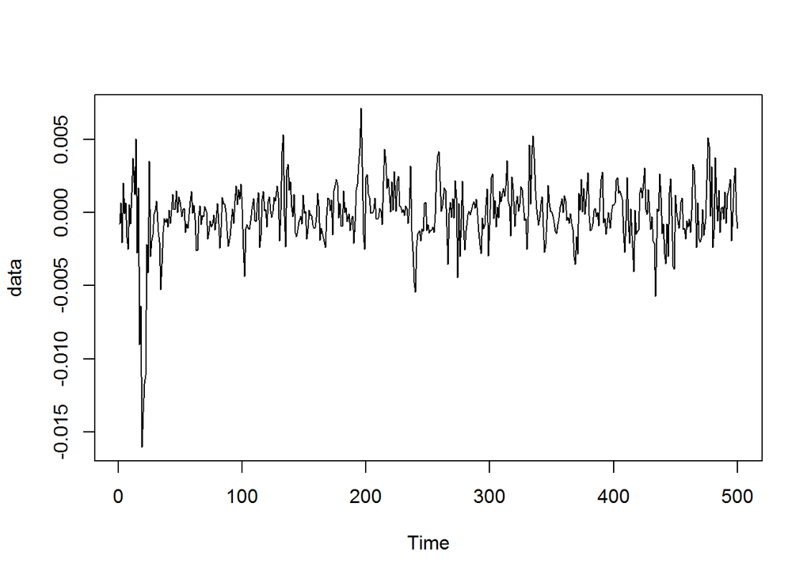

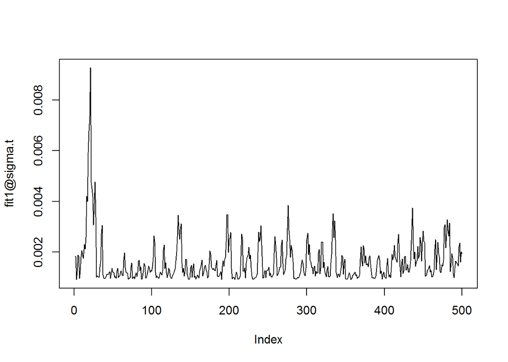

The variance is well explained by our model. Let’s also check the diagnostic plots (auto correlation of residuals and squared residuals):

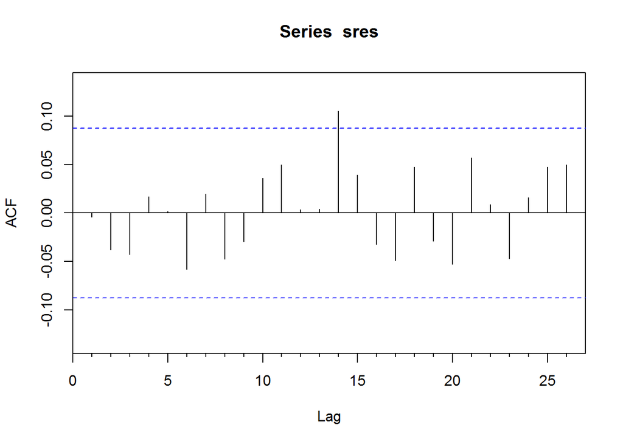

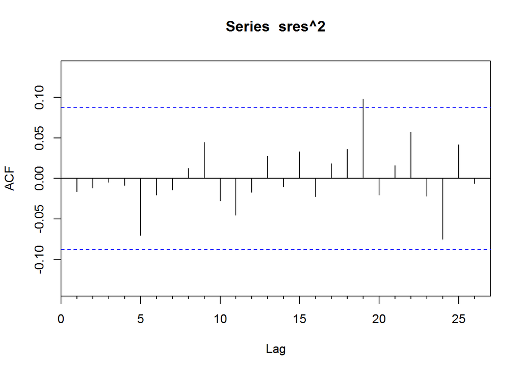

There is only one significant lag with a very low value so we can state that there is no correlation at any lag for the residuals and squared residuals. Let’s test it:

```
##
##  Box-Ljung test
##
## data:  sres
## X-squared = 13.008, df = 14, p-value = 0.5259
```

```
##
##  ARCH LM-test; Null hypothesis: no ARCH effects
##
## data:  sres
## Chi-squared = 18.254, df = 19, p-value = 0.5055
```

The p-value for both test is over significance level so we don’t reject null hypothesis and assume there is not correlation as expected.

**1.d. Write down your final fitted model.**

This is the final model:

x(t) = -3.548e-01 x(t-1) + 4.326e-01 x(t-2) + 8.584e-01 a(t-1) + at

a(t)=sigma(t)e(t)

sigma2(t) = 3.190e-01xa2(t-1) + 4.637e-01xa2(t-2)

E(a(t))=0

**2.a. Build a GARCH model for the log returns (see Lecture 1 for definitions of simple and log returns) of GM stock. Justify your choice of model and confirm all assumptions.**

We are going to built a GARCH model for the log returns so let’s take the log of the returns (`lgm = log(1+gm)`) and plot the data:

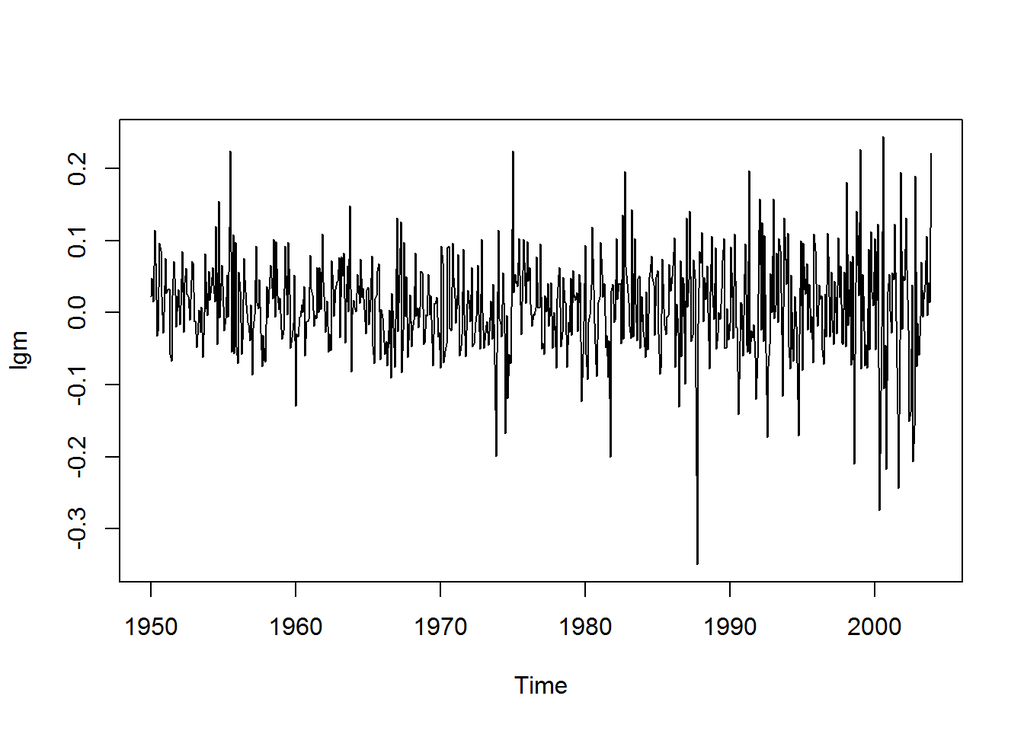

Let’s check if the mean of the series is 0 to see if we need the constant alpha0 in the ARMA model. We’ll test null hypothesis mean=0:

```
##   Start Size       Mean Standard.Deviation   Skewness Excess.Kurtosis
## 1  1950  648 0.00850659         0.06936185 -0.2716103        2.247977
##      Minimum  Maximum
## 1 -0.3498128 0.244216
```

```
## [1] 0.0008983664
```

p-value (`0.0008983664`) for mean = 0 is very low so we reject the null hypothesis and conclude that the mean is not 0, thus, we need a constant for our ARMA(p,q) model:

x(t) = alpha0 + alpha1 x(t-1) + … + alphap x(t-p) + beta1 a(t-1) + … + betaq a(t-q) + at

Now, we check auto correlation and partial auto correlation plots:

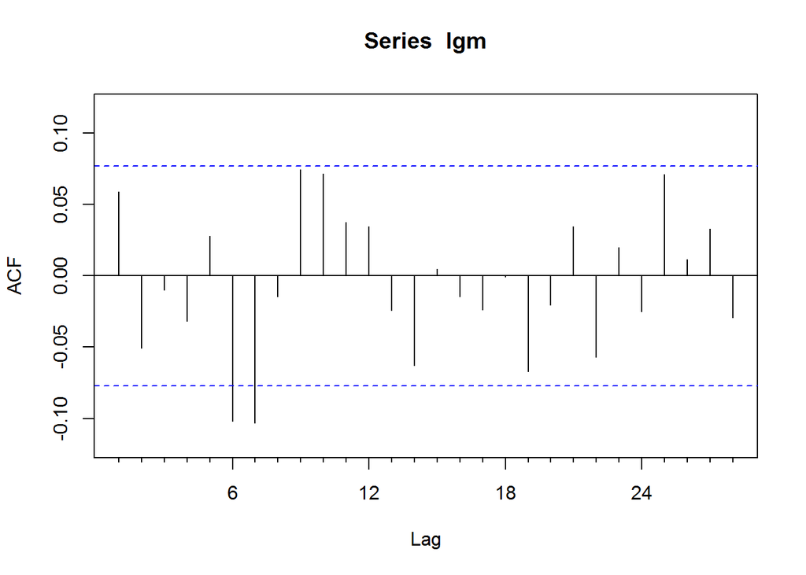

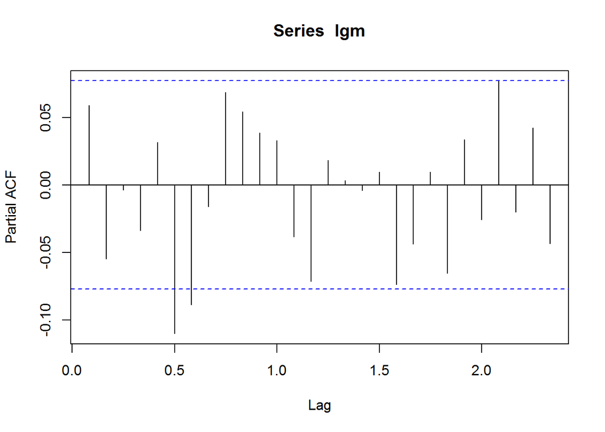

It looks there is correlation at lag 6 and 7. Let’s confirm with a Box-Ljung test:

```
##
##  Box-Ljung test
##
## data:  lgm
## X-squared = 18.934, df = 7, p-value = 0.008396
```

The p-value is lower than our significance level so we reject null hypothesis (no correlation) and state that there is correlation at lag 7.

After checking the output for `auto.arima` we find that the model with best AIC (`-1626.345`) is **ARMA(p=2,q=6)** [x(t) = alpha0 + alpha1 x(t-1) + alpha2 x(t-2) + beta1 a(t-1) + beta2 a(t-2) + beta3 a(t-3) + beta4 a(t-4) + beta5 a(t-5) + beta6 a(t-6)+ a(t)]:

```
##
## Call:
## arima(x = lgm, order = c(2, 0, 6))
##
## Coefficients:
##         ar1      ar2      ma1     ma2     ma3      ma4     ma5      ma6
##       0.943  -0.6260  -0.8915  0.5316  0.0904  -0.0659  0.0646  -0.1514
## s.e.  0.210   0.1369   0.2096  0.1337  0.0599   0.0577  0.0574   0.0507
##       intercept
##          0.0084
## s.e.     0.0023
##
## sigma^2 estimated as 0.004607:  log likelihood = 823.52,  aic = -1627.05
```

This model has several coefficients that are not significant but they are not the highest order term so we leave it as it is and proceed with a GARCH model. But first, let’s check the diagnostic plots to verify that this ARMA model is a good fit for the data:

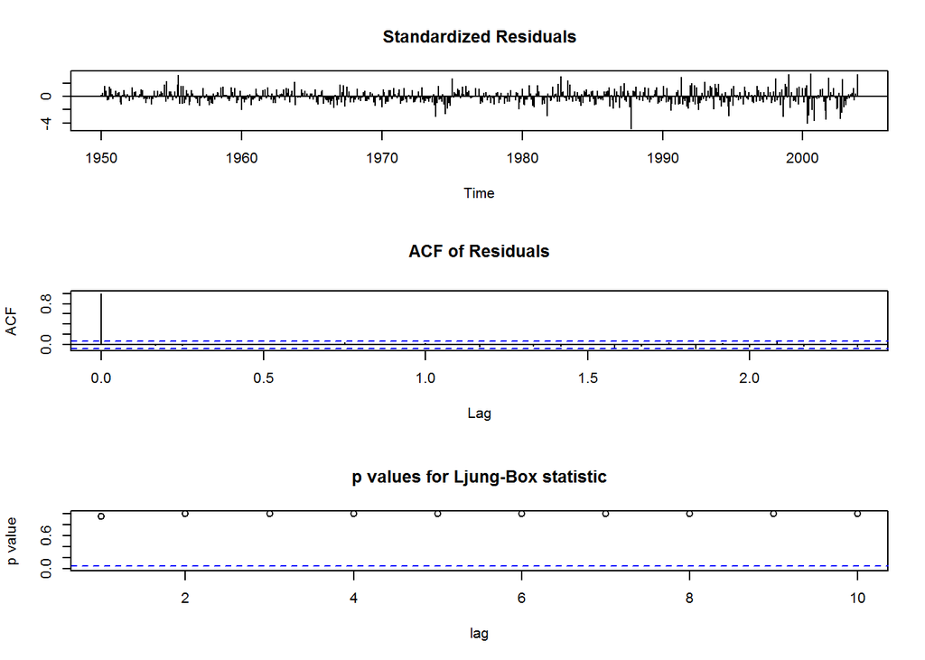

As we can see there is no correlation in the residuals. On the other hand variance is not constant. It looks like there is a volatility cluster at the end. Let’s see if there are conditional heteroscedastic effects checking the correlation of squared residuals:

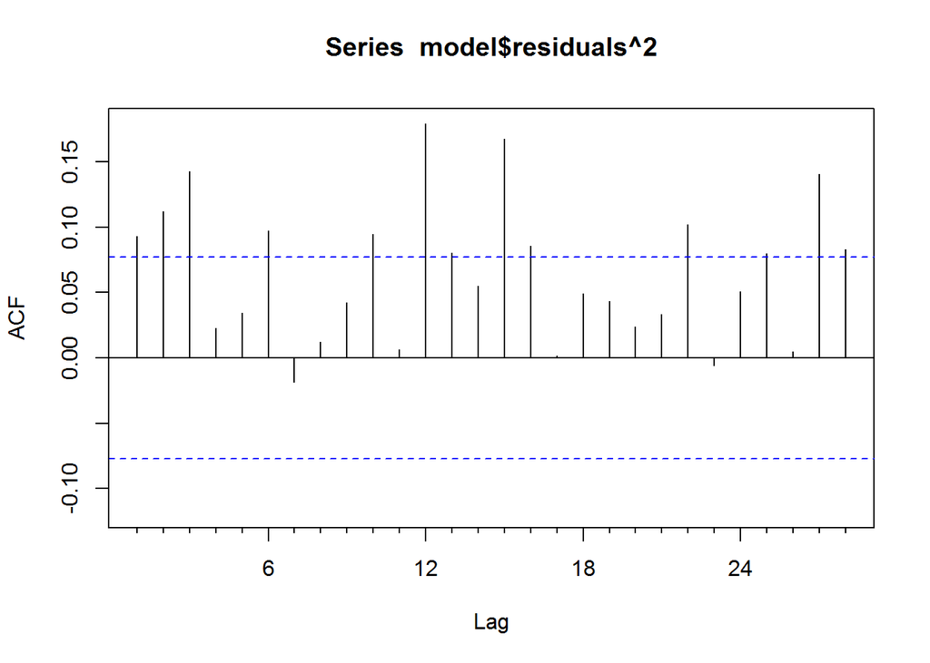

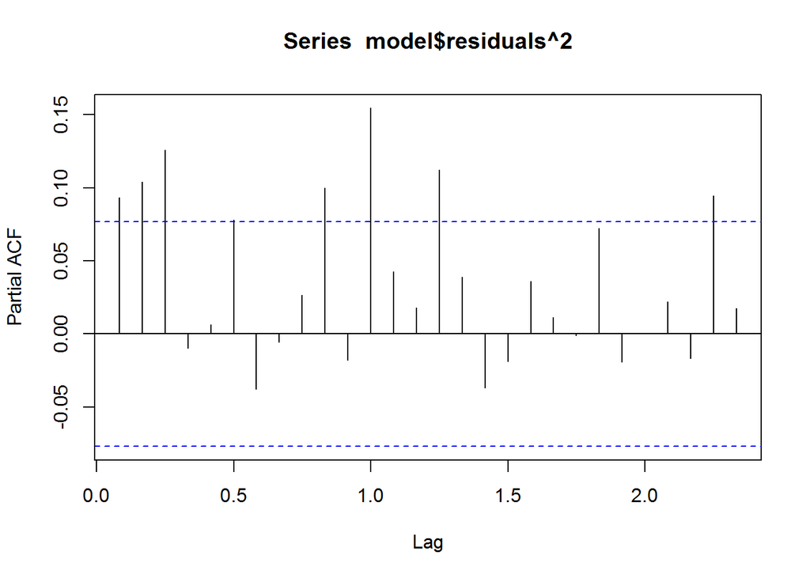

It looks like there is correlation, let’s test with the Box-Ljung test at lag n on the auto correlations of the squared residual values. Null hypothesis is that there is no correlation at lag n. We test for lag 3 and 15:

```
##
##  ARCH LM-test; Null hypothesis: no ARCH effects
##
## data:  model$residuals
## Chi-squared = 23.079, df = 3, p-value = 3.887e-05
```

```
##
##  ARCH LM-test; Null hypothesis: no ARCH effects
##
## data:  model$residuals
## Chi-squared = 58.767, df = 15, p-value = 4.104e-07
```

The p-value is smaller that the significant level so we reject the null hypothesis, thus, there is correlation.

There is conditional heteroscedastic effects so we are going to use an GARCH(m,s) model.

We fit a GARCH(m,s) with m = 1 and s = 1 (we have tried several models and this one yields the best AIC):

```
##
## Title:
##  GARCH Modelling
##
## Call:
##  garchFit(formula = ~arma(2, 6) + garch(1, 1), data = lgm, trace = FALSE)
##
## Mean and Variance Equation:
##  data ~ arma(2, 6) + garch(1, 1)
## <environment: 0x000000000cfb1fd0>
##  [data = lgm]
##
## Conditional Distribution:
##  norm
##
## Coefficient(s):
##         mu         ar1         ar2         ma1         ma2         ma3
##  0.0089554   0.5184838  -0.4527858  -0.4500204   0.3797284   0.0630363
##        ma4         ma5         ma6       omega      alpha1       beta1
## -0.0329795   0.0674404  -0.1117976   0.0001399   0.0804775   0.8935482
##
## Std. Errors:
##  based on Hessian
##
## Error Analysis:
##          Estimate  Std. Error  t value Pr(>|t|)
## mu      8.955e-03   6.481e-03    1.382  0.16706
## ar1     5.185e-01   3.577e-01    1.449  0.14723
## ar2    -4.528e-01   3.232e-01   -1.401  0.16117
## ma1    -4.500e-01   3.652e-01   -1.232  0.21790
## ma2     3.797e-01   3.348e-01    1.134  0.25665
## ma3     6.304e-02   5.055e-02    1.247  0.21239
## ma4    -3.298e-02   4.864e-02   -0.678  0.49771
## ma5     6.744e-02   4.721e-02    1.429  0.15314
## ma6    -1.118e-01   7.797e-02   -1.434  0.15163
## omega   1.399e-04   7.098e-05    1.971  0.04874 *
## alpha1  8.048e-02   2.559e-02    3.145  0.00166 **
## beta1   8.935e-01   3.205e-02   27.879  < 2e-16 ***
## ---
## Signif. codes:  0 '***' 0.001 '**' 0.01 '*' 0.05 '.' 0.1 ' ' 1
```

[output cut: 8 more lines]

```
## Standardised Residuals Tests:
##                                 Statistic p-Value
##  Jarque-Bera Test   R    Chi^2  45.0333   1.663961e-10
##  Shapiro-Wilk Test  R    W      0.9865018 1.074589e-05
##  Ljung-Box Test     R    Q(10)  2.188855  0.994677
##  Ljung-Box Test     R    Q(15)  6.3944    0.9723344
##  Ljung-Box Test     R    Q(20)  12.50613  0.8975554
##  Ljung-Box Test     R^2  Q(10)  7.563172  0.6714207
##  Ljung-Box Test     R^2  Q(15)  18.15279  0.2547183
##  Ljung-Box Test     R^2  Q(20)  21.77444  0.3528743
##  LM Arch Test       R    TR^2   14.44853  0.2729873
##
## Information Criterion Statistics:
##       AIC       BIC       SIC      HQIC
## -2.588292 -2.505442 -2.588961 -2.556152
```

Notice that highest order term ma6 is not significant so we remove it and fit the model again:

```
##
## Title:
##  GARCH Modelling
##
## Call:
##  garchFit(formula = ~arma(2, 5) + garch(1, 1), data = lgm, trace = FALSE)
##
## Mean and Variance Equation:
##  data ~ arma(2, 5) + garch(1, 1)
## <environment: 0x000000000b88a968>
##  [data = lgm]
##
## Conditional Distribution:
##  norm
##
## Coefficient(s):
##          mu          ar1          ar2          ma1          ma2
##  0.01198108  -0.55301785   0.40760794   0.64046030  -0.43653663
##         ma3          ma4          ma5        omega       alpha1
## -0.03476516  -0.01839228  -0.02781768   0.00014934   0.08701499
##       beta1
##  0.88333328
##
## Std. Errors:
##  based on Hessian
##
## Error Analysis:
##          Estimate  Std. Error    t value Pr(>|t|)
## mu      1.198e-02   2.235e-06   5361.069  < 2e-16 ***
## ar1    -5.530e-01   3.058e-05 -18082.724  < 2e-16 ***
## ar2     4.076e-01   2.891e-05  14099.120  < 2e-16 ***
## ma1     6.405e-01   3.609e-05  17744.057  < 2e-16 ***
## ma2    -4.365e-01   3.872e-05 -11273.142  < 2e-16 ***
## ma3    -3.477e-02   3.908e-05   -889.552  < 2e-16 ***
## ma4    -1.839e-02   3.902e-05   -471.339  < 2e-16 ***
## ma5    -2.782e-02   3.656e-05   -760.859  < 2e-16 ***
## omega   1.493e-04   8.846e-05      1.688  0.09134 .
## alpha1  8.701e-02   3.194e-02      2.725  0.00644 **
## beta1   8.833e-01   4.447e-02     19.864  < 2e-16 ***
## ---
```

[output cut: 9 more lines]

```
## Standardised Residuals Tests:
##                                 Statistic p-Value
##  Jarque-Bera Test   R    Chi^2  36.99951  9.239727e-09
##  Shapiro-Wilk Test  R    W      0.9879159 3.450152e-05
##  Ljung-Box Test     R    Q(10)  11.8601   0.2945283
##  Ljung-Box Test     R    Q(15)  15.17855  0.4386341
##  Ljung-Box Test     R    Q(20)  21.79553  0.3517082
##  Ljung-Box Test     R^2  Q(10)  8.001781  0.628663
##  Ljung-Box Test     R^2  Q(15)  17.65356  0.2813168
##  Ljung-Box Test     R^2  Q(20)  20.42325  0.4317489
##  LM Arch Test       R    TR^2   15.0061   0.2411032
##
## Information Criterion Statistics:
##       AIC       BIC       SIC      HQIC
## -2.625284 -2.549339 -2.625848 -2.595823
```

Let’s plot the fitted standard deviation estimates and fitted series values next to the original series to see if it matches:

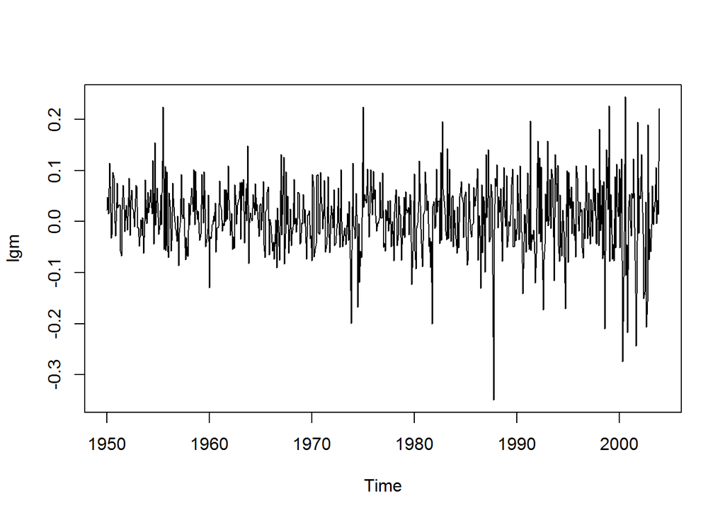

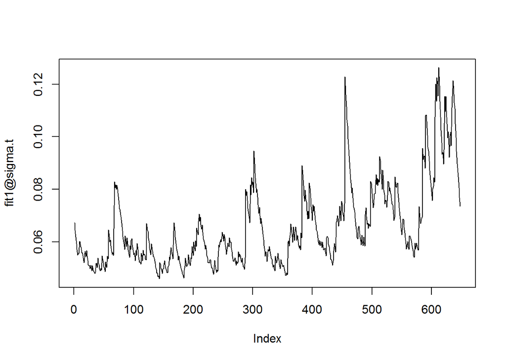

It looks like the variance is well explained by the model. Now we plot the standardized residuals:

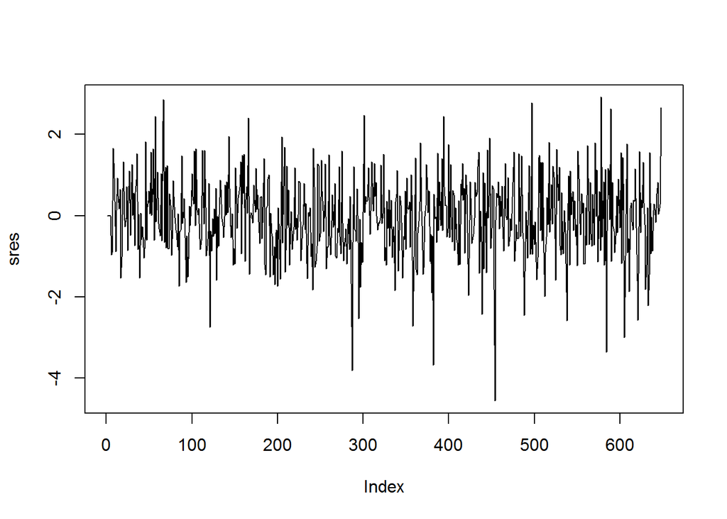

Mean looks like 0 and variance constant.

Let’s also check the diagnostic plots (auto correlation of residuals and squared residuals):

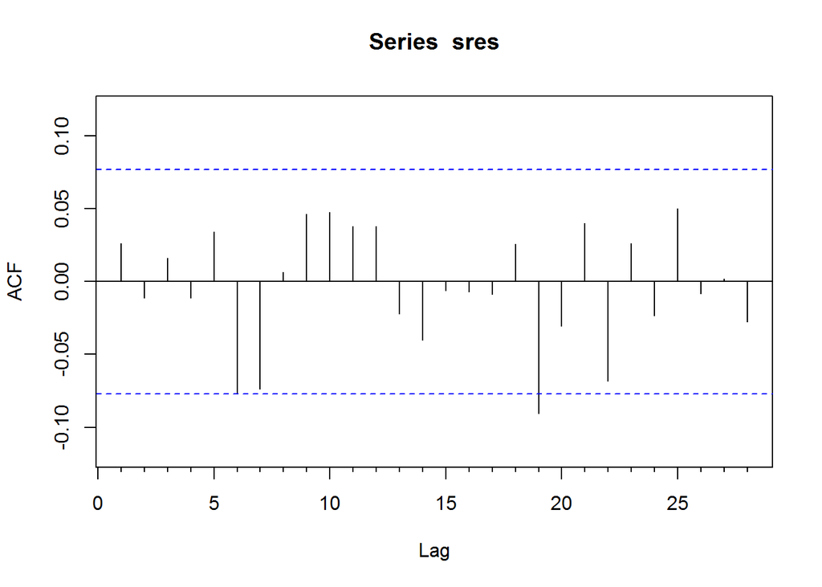

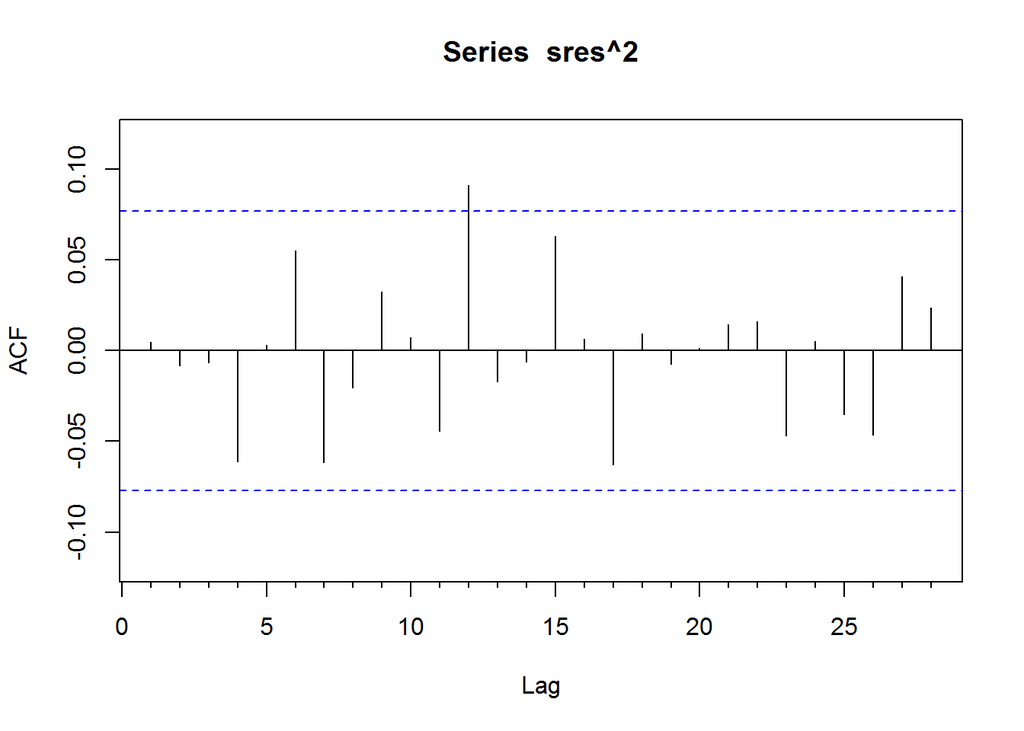

There is only one significant lag with a very low value so we can state that there is no correlation at any lag for the residuals and squared residuals. We can check doing a Box-Ljung test at lag 12:

```
##
##  ARCH LM-test; Null hypothesis: no ARCH effects
##
## data:  sres
## Chi-squared = 15.006, df = 12, p-value = 0.2411
```

As we suspected, there is no correlation (we don’t reject the null hypothesis).

**2.b. Write down the fitted model.**

This is the final model:

x(t) = 1.198e-02 - 5.530e-0 x(t-1) + 4.076e-01 x(t-2) + 6.405e-0 a(t-1) - 4.365e-01 a(t-) - 3.477e-02 a(t-3) - 1.839e-02 a(t-4) - 2.782e-02 a(t-5) + a(t)

a(t)=sigma(t)e(t)

sigma2(t) = 8.701e-02 x a2(t-1) + 8.833e-01 x sigma2(t-1)

E(a(t))=0

**2.c. Forecast the log returns for the next three month after the end of the series.**

Let’s make and plot the predictions:

```
##   meanForecast  meanError standardDeviation
## 1   0.01808676 0.09094019        0.09094019
## 2   0.00207868 0.09076054        0.09041150
## 3   0.01018252 0.09051577        0.08989552
```

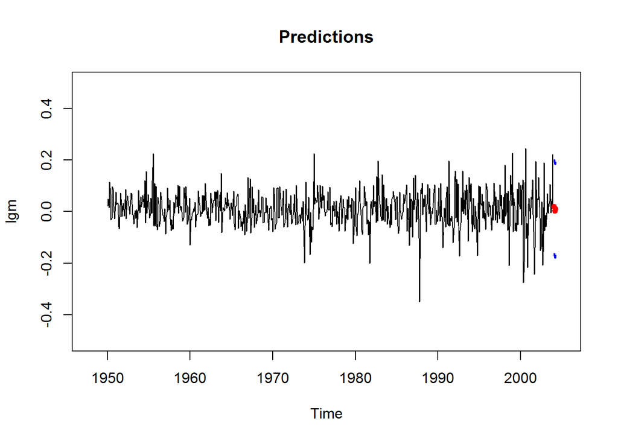

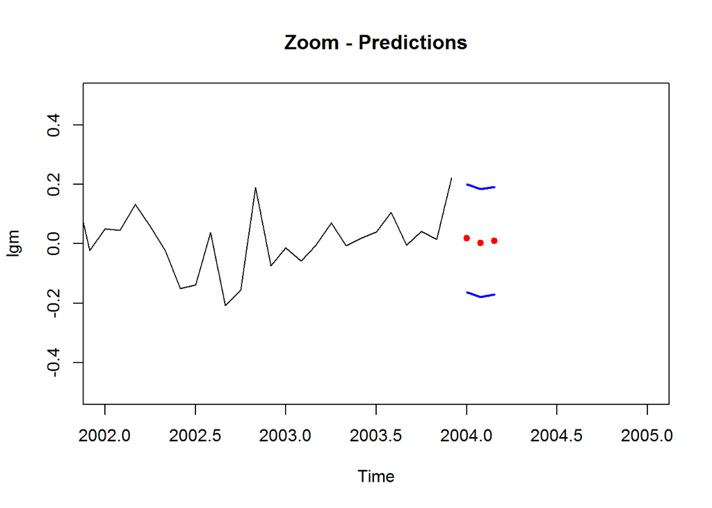